### Part D

As you can see from the plot below, there are a few issues with the fit:

- There are some unusually large outliers in the residuals vs. the fitted (up in the top right hand corner and bottom right). The model fits our data well on the left, but the variance spreads out as we move rightwards.
- Nearly all observations are clustered on the left, but then there’s one all the way off to the right with an extremely high leverage. This smells fishy…

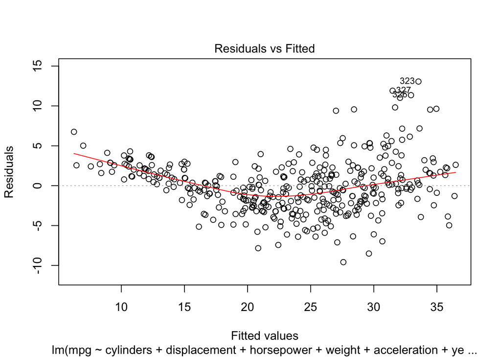

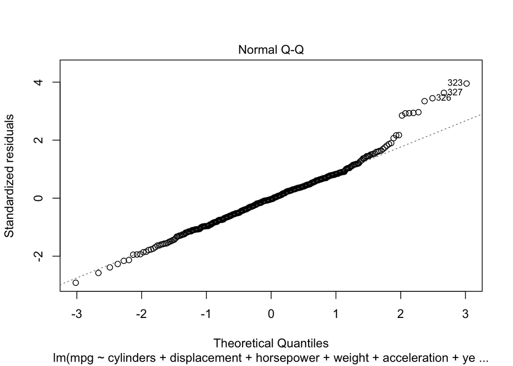

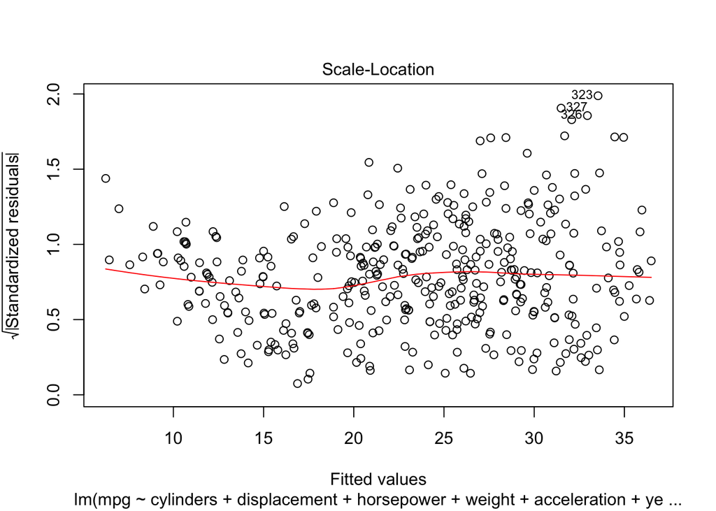

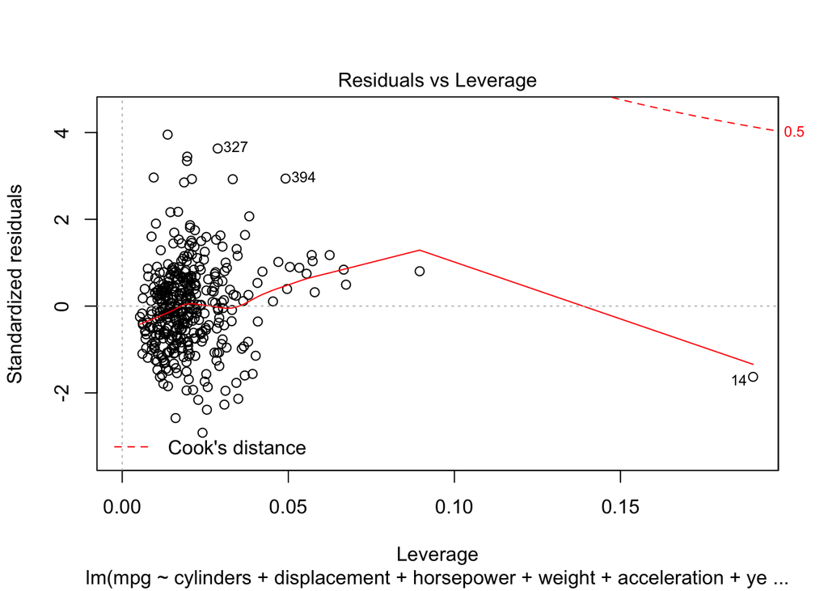

```r
plot(Auto.fit)
```